# MediaStack News Source Prediction

Anurag, Ashutosh, Nikhil, Sohaib

2022-12-07

```r
knitr::opts_chunk$set(fig.width=12, fig.height=8)
```

## Business Context

We are using mediastack REST API interface which provides worldwide live and historical news data. The API provides multiple parameters such as ‘Category’, ‘language’,‘source’,etc to get the required news articles.

## Problem Description

When we go through a news article online, we are always concerned whether our news is coming from the right source.

Media stack has news articles from multiples sources/channels. Our goal is to train ML models that can predict the source of the news based on the content provided.

## Load Relevant Libraries

```r
library(httr)
library(tidyverse)
library(repurrrsive)
library(stringr)
library(dplyr)
library(RColorBrewer)
library(ggthemes)
library(keras)
library(tokenizers)
library(kableExtra)
```

## Download csv file of data collected from the API

```r
data <- read.csv("C:/CIS8398/Data/myDataBaseFinal1.csv")
```

## Filtering News that are longer than 100 characters

```r
desired_length =  100
df = data %>%
  filter(str_count(description) >= desired_length) %>%
  select(title:source)
```

## Data Summary

```r
dt <- head(df)
dt %>%
  kbl() %>%
  kable_styling()
```

| title | description | category | source |
| --- | --- | --- | --- |
| China warns of ‘counter-measures’ as US approves $1.1bn arms sales to Taiwan | China has warned the United States it will take “counter-measures” after the Biden administration approved more than $1.1 billion in arms sales to Taiwan. | general | CNN |
| Watch: Video shows pilot flying in Mississippi | A pilot in Tupelo, Mississippi, is threatening to intentionally crash a small plane into a Walmart, police said. CNN national correspondent Nadia Romero and aviation analyst Miles O’Brien have more. | general | CNN |
| LGBTQ activists call for protests at Peruvian embassies after Harvard grad’s death in Bali | The death of a transgender Harvard graduate student in police custody in Bali is causing anger in his native Peru, where activists are calling for protests outside Peruvian embassies and consulates ar… | general | CNN |
| The judge is considering temporarily blocking the DOJ from accessing the materials for its criminal probe if she appoints a special master, reports say | The judge is considering temporarily blocking the DOJ from accessing the materials for its criminal probe if she appoints a special master, reports say | general | CNN |
| Iran’s Arab foes are mending ties with Tehran amid uncertainty over nuclear talks | Analysts say Gulf Arab states expect Iran to escalate tensions in the region no matter the outcome of the nuclear talks. | general | CNN |
| ‘Outbursts’ from Pakistan’s melting glaciers have tripled this year and are worsening floods | Pakistan is home to more glaciers than anywhere in the world outside the polar regions, but as the climate warms, it’s becoming more vulnerable to sudden outbursts of melting glacier water that have t… | general | CNN |

The Data has 4 columns which are:

- Title
- Description
- Category
- Source

For our modeling we will be using Description to predict the source of news

## Data Exploration

Below are the different news sources and the counts of their respective articles in our dataset

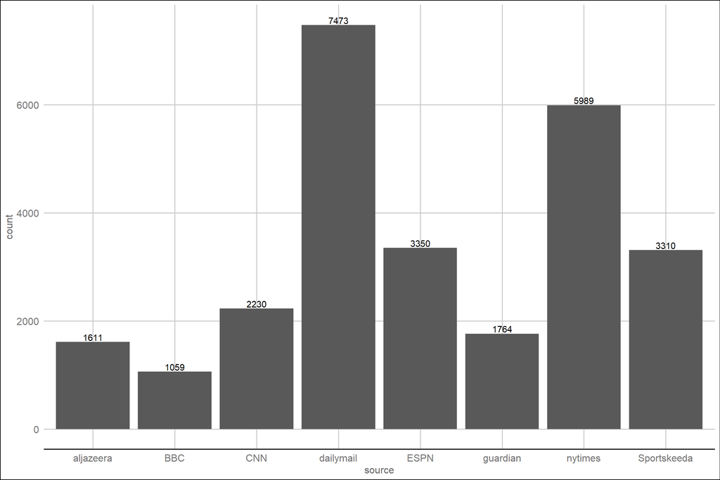

```r
df3 <- df %>%
  count(source)

names(df3)[2] <- "count"

ggplot(data=df3, aes(y=count, x=source)) +
  geom_bar(position="dodge", stat="identity")+
  geom_text(aes(label=count),vjust = -0.2, position = position_dodge(.9))+
  theme_gdocs()+
  scale_color_gdocs()+
  scale_fill_brewer(palette = "Paired")
```

The plot below shows the counts of different news categories for each news source

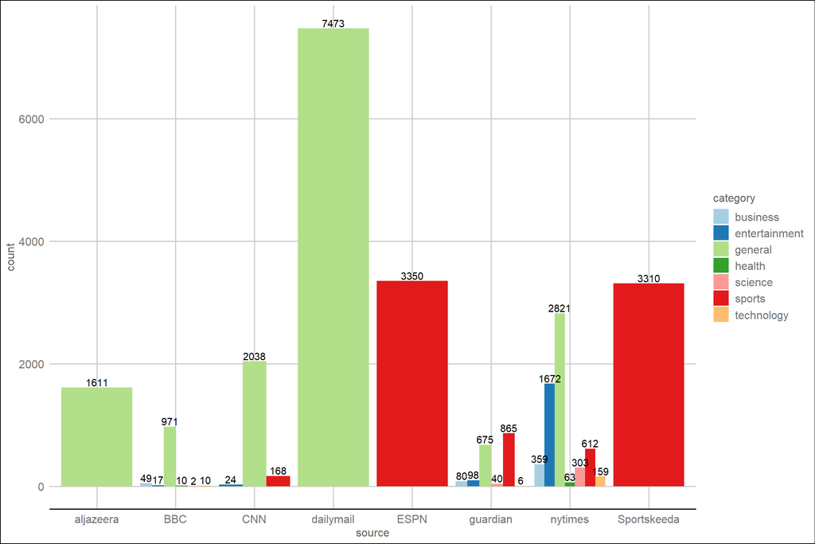

```r
df2 <- df %>%
  group_by(source,category)%>%
  count(source)

names(df2)[3] <- "count"

ggplot(data=df2, aes(fill=category, y=count, x=source)) +
  geom_bar(position="dodge", stat="identity")+
  geom_text(aes(label=count),vjust = -0.2, position = position_dodge(.9))+
  theme_gdocs()+
  scale_color_gdocs()+
  scale_fill_brewer(palette = "Paired")
```

The final data exploratory plot shows the length of news article descriptions in our dataset

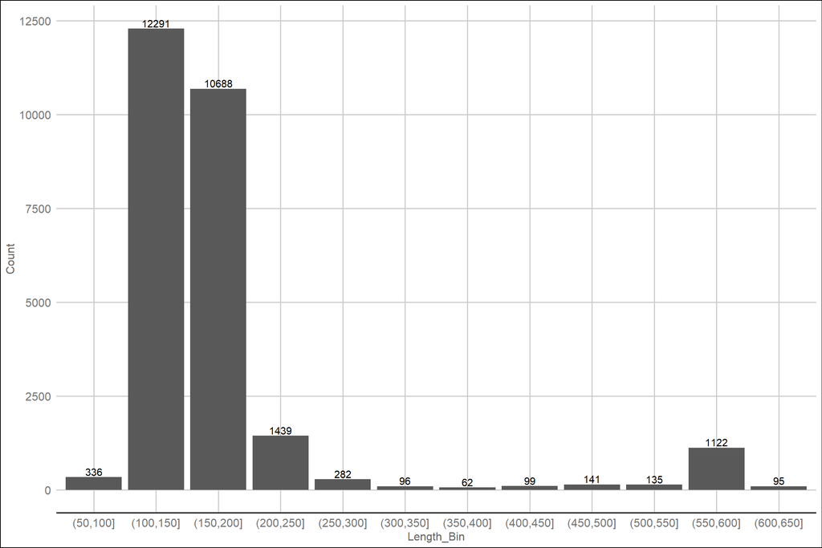

```r
df_length <- df%>%
  mutate(description_length = str_count(description))

vec1 <- df_length$description_length

DT <- df_length %>%
  group_by(gr=cut(vec1, breaks= seq(0, 650, by = 50)) ) %>%
  summarise(n= n()) %>%
  arrange(as.numeric(gr))

names(DT)[1] <- "Length_Bin"
names(DT)[2] <- "Count"

ggplot(data=DT, aes(y=Count, x=Length_Bin)) +
  geom_bar(position="dodge", stat="identity")+
  geom_text(aes(label=Count),vjust = -0.2, position = position_dodge(.9))+
  theme_gdocs()+
  scale_color_gdocs()
```

```r
myData <- df
```

## AI/ML Procedure Summary

defining the default parameters

```r
max_words <- 10000
maxlen <- 400
training_samples <- as.integer(0.75 * dim(myData)[1])
validation_samples <- as.integer(0.25 * dim(myData)[1])
tokenizer <- text_tokenizer(num_words = max_words) %>% fit_text_tokenizer(myData$description)
```

```
## Loaded TensorFlow version 2.10.0
```

```r
sequences <- texts_to_sequences(tokenizer, myData$description)
word_index = tokenizer$word_index
cat("Found",length(word_index), "unique tokens. \n")
```

```
## Found 51937 unique tokens.
```

padding sequences to make them of equal length

```r
data <- pad_sequences(sequences, maxlen = maxlen)
labels <- as.array(as.numeric(factor(myData$source)))
cat("Shape of data tensor (Num Docs, Num Words in a Doc):", dim(data), "\n")
```

```
## Shape of data tensor (Num Docs, Num Words in a Doc): 26786 400
```

```r
cat('Shape of label tensor (Num Docs):', dim(labels), "\n")
```

```
## Shape of label tensor (Num Docs): 26786
```

```r
unique(labels)
```

```
## [1] 3 2 6 7 1 5 8 4
```

```r
length(unique(labels))
```

```
## [1] 8
```

Training and Validation split

```r
set.seed(123)
indices <- sample(1:nrow(data))

training_indices <- indices[1:training_samples]
validation_indices <- indices[(training_samples + 1):
                                (training_samples + validation_samples)]
x_train <- data[training_indices,]
y_train <- labels[training_indices]
x_val <- data[validation_indices,]
y_val <- labels[validation_indices]
y_val<- to_categorical(y_val)
y_train <- to_categorical(y_train)
dim(x_train)
```

```
## [1] 20089   400
```

```r
dim(y_train)
```

```
## [1] 20089     9
```

```r
dim(x_val)
```

```
## [1] 6696  400
```

```r
dim(y_val)
```

```
## [1] 6696    9
```

## nn_embd

```
## [1] 100
```

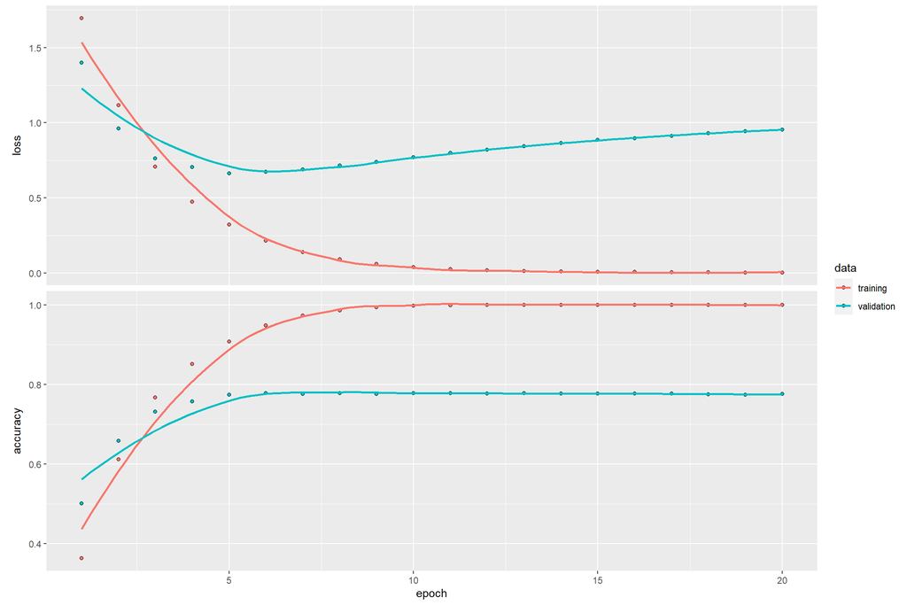

```
##     loss accuracy
## 0.954033 0.775687
## [1] 200
```

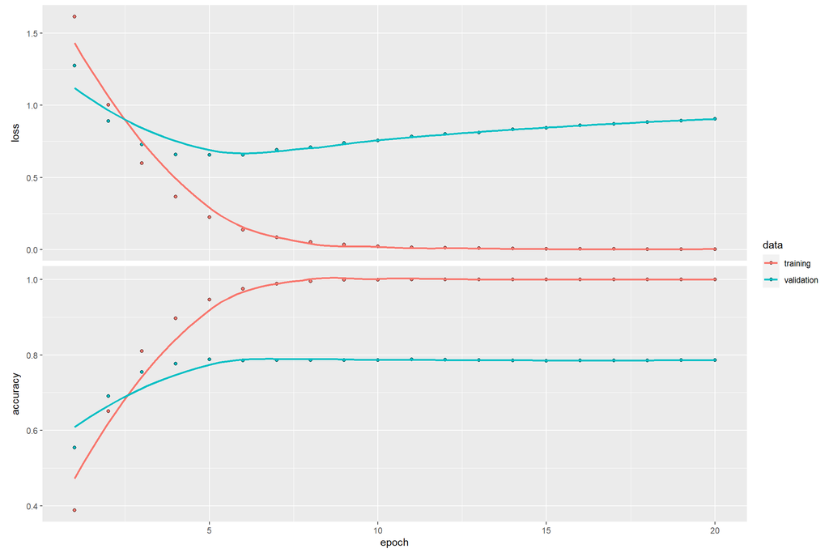

```
##      loss  accuracy
## 0.9052626 0.7864397
## [1] 300
```

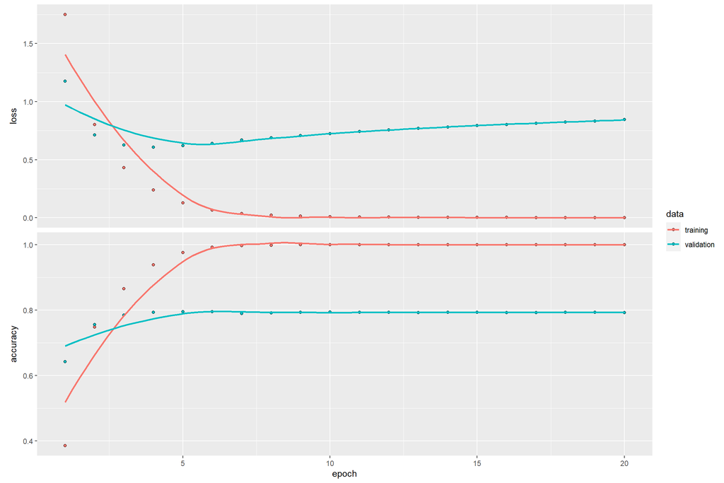

```
##      loss  accuracy
## 0.8446380 0.7927121
## [1] 400
```

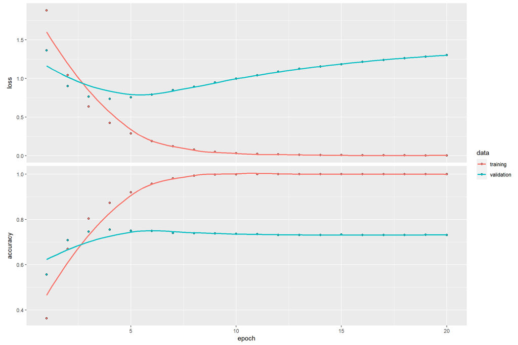

```
##      loss  accuracy
## 1.3037027 0.7317802
```

```r
embedding_sizes = c(100,200,300,400)
result_list = c()
for (embedding in embedding_sizes){
  print(embedding)
  embedding_dim <- embedding
  model <- keras_model_sequential() %>%
    layer_embedding(input_dim = max_words,
                    input_length = maxlen,
                    output_dim = embedding_dim) %>%
    layer_flatten() %>%
    layer_dense(units = 32, activation = "relu") %>%
    layer_dense(units = dim(y_train)[2], activation = "softmax")

  model %>% compile(
    optimizer = "adam",
    loss = "categorical_crossentropy",
    metrics = c("accuracy")
  )

  history <- model %>% fit(
    x_train, y_train,
    epochs = 20,
    batch_size = 256,
    validation_data = list(x_val, y_val)
  )
  model %>% save_model_hdf5("nn_100.h5")
  print(plot(history))
  results <- model %>% evaluate(x_val, y_val)
  print(results)
  result_list = append(result_list,results)
}
```

## rnn model

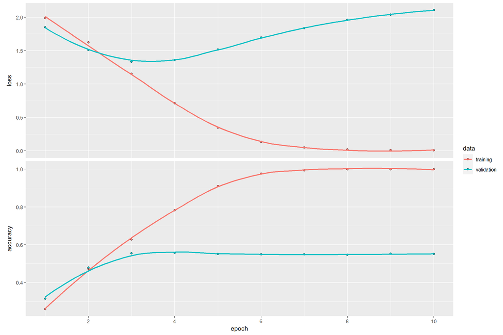

```r
output_dim = 32
embedding_dim = 100
model_rnn <- keras_model_sequential() %>%
  layer_embedding(input_dim = max_words, output_dim = embedding_dim) %>%
  layer_simple_rnn(units = output_dim) %>%
  layer_dense(units = 32, activation = "relu") %>%
  layer_dense(units = dim(y_train)[2], activation = "softmax")

model_rnn %>% compile(
  optimizer = "adam",
  loss = "categorical_crossentropy",
  metrics = c("accuracy")
)

history <- model_rnn %>% fit(
  x_train, y_train,
  epochs = 10,
  batch_size = 256,
  validation_split = 0.2
)
plot(history)
```

```r
results_rnn <- model_rnn %>% evaluate(x_val, y_val)
print(results_rnn)
```

```
##      loss  accuracy
## 2.0452986 0.5536141
```

```r
result_list = append(result_list,results_rnn)

model_rnn %>% save_model_hdf5("rnn.h5")
```

## Multilayer RNN

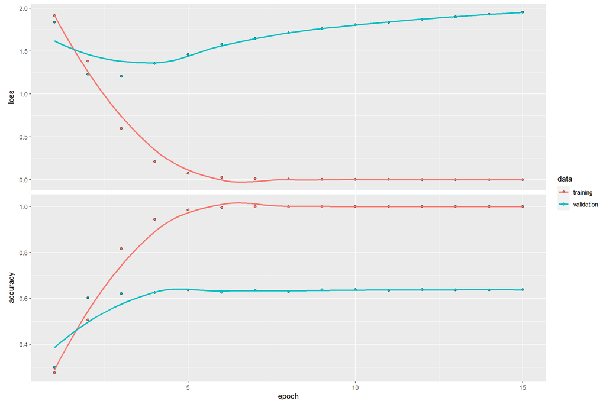

```r
output_dim = 32
embedding_dim = 100
model_mlrnn <- keras_model_sequential() %>%
  layer_embedding(input_dim = max_words, output_dim = embedding_dim) %>%
  layer_simple_rnn(units = output_dim, return_sequences = TRUE) %>%
  layer_simple_rnn(units = output_dim, return_sequences = TRUE) %>%
  layer_simple_rnn(units = output_dim, return_sequences = TRUE) %>%
  layer_simple_rnn(units = output_dim) %>%
  layer_dense(units = 32, activation = "relu") %>%
  layer_dense(units = dim(y_train)[2], activation = "softmax")

model_mlrnn %>% compile(
  optimizer = "adam",
  loss = "categorical_crossentropy",
  metrics = c("accuracy")
)

history <- model_mlrnn %>% fit(
  x_train, y_train,
  epochs = 15,
  batch_size = 256,
  validation_split = 0.2
)
plot(history)
```

```r
results_mlrnn <- model_mlrnn %>% evaluate(x_val, y_val)
print(results_mlrnn)
```

```
##      loss  accuracy
## 1.9497281 0.6324672
```

```r
result_list = append(result_list,results_mlrnn)

model_mlrnn %>% save_model_hdf5("mlrnn.h5")
```

## LSTM

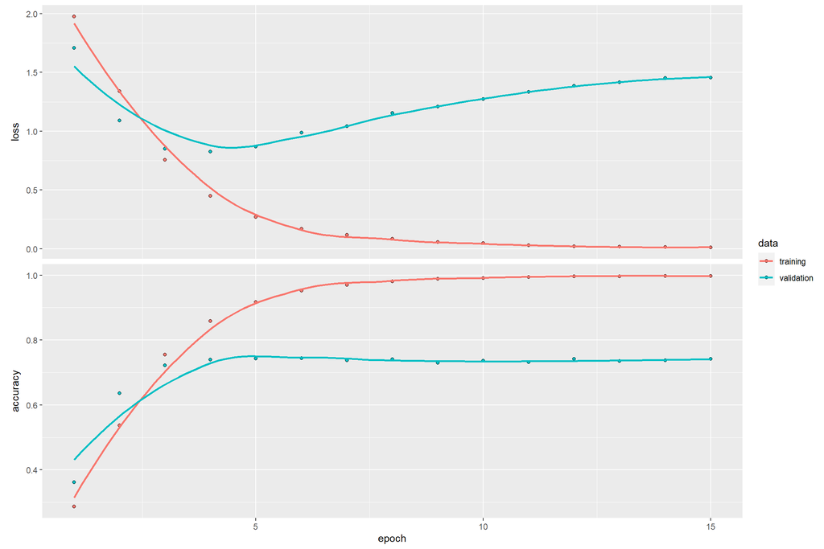

```r
output_dim = 32
embedding_dim = 100
model_lstm <- keras_model_sequential() %>%
  layer_embedding(input_dim = max_words, output_dim = embedding_dim) %>%
  layer_lstm(units = output_dim) %>%
  layer_dense(units = 32, activation = "relu") %>%
  layer_dense(units = dim(y_train)[2], activation = "softmax")

model_lstm %>% compile(
  optimizer = "adam",
  loss = "categorical_crossentropy",
  metrics = c("accuracy")
)

history <- model_lstm %>% fit(
  x_train, y_train,
  epochs = 15,
  batch_size = 256,
  validation_split = 0.2
)
plot(history)
```

```r
results_lstm <- model_lstm %>% evaluate(x_val, y_val)
results_lstm
```

```
##      loss  accuracy
## 1.5543120 0.7307348
```

```r
result_list = append(result_list,results_lstm)

model_lstm %>% save_model_hdf5("lstm.h5")
```

## Bi-directional LSTM

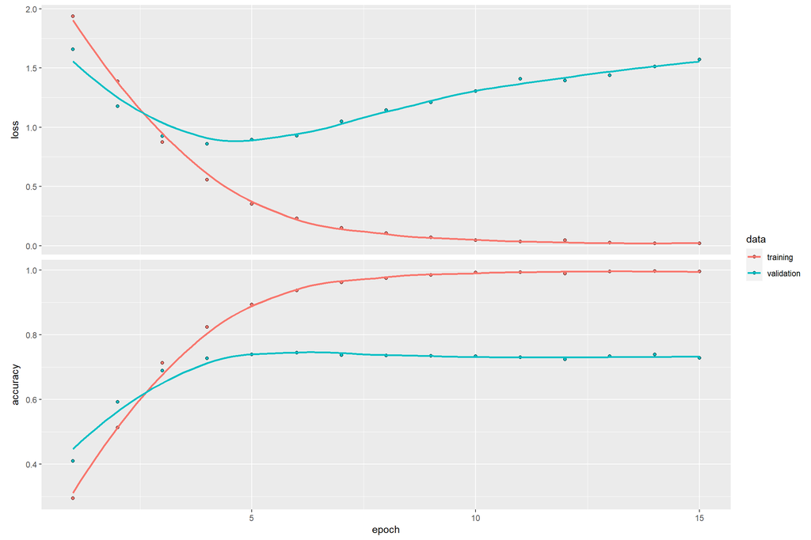

```r
output_dim = 32
embedding_dim = 100
model_bilstm <- keras_model_sequential() %>%
  layer_embedding(input_dim = max_words, output_dim = embedding_dim) %>%
  bidirectional(layer_lstm(units = output_dim)) %>%
  layer_dense(units = 32, activation = "relu") %>%
  layer_dense(units = dim(y_train)[2], activation = "softmax")

model_bilstm %>% compile(
  optimizer = "adam",
  loss = "categorical_crossentropy",
  metrics = c("accuracy")
)

history <- model_bilstm %>% fit(
  x_train, y_train,
  epochs = 15,
  batch_size = 256,
  validation_split = 0.2
)
plot(history)
```

```r
results_bilstm <- model_bilstm %>% evaluate(x_val, y_val)
results_bilstm
```

```
##      loss  accuracy
## 1.7037780 0.7135603
```

```r
result_list = append(result_list,results_bilstm)

model_bilstm %>% save_model_hdf5("bilstm.h5")
```

## 1d convo

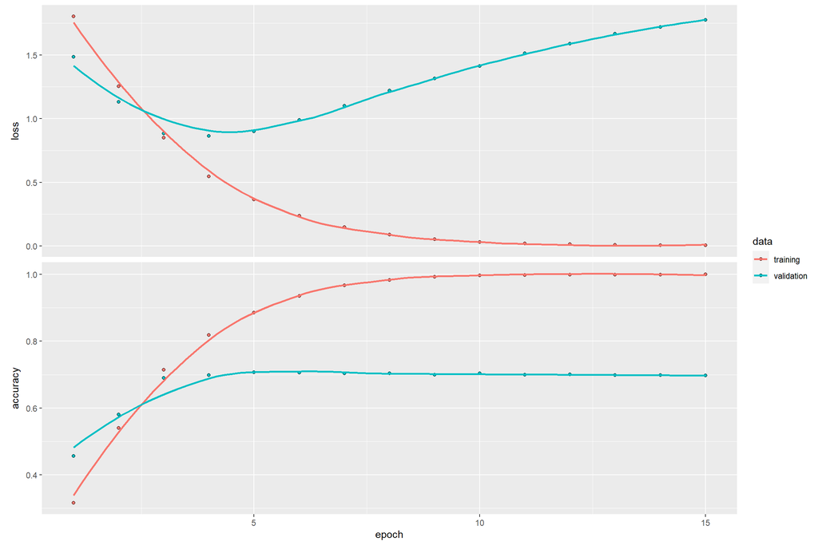

```r
filter_size = 32
embedding_dim = 128
model_1dcnn <- keras_model_sequential() %>%
  layer_embedding(input_dim = max_words, output_dim = embedding_dim, input_length = maxlen) %>%
  layer_conv_1d(filters = 32, kernel_size = 7, activation = "relu") %>%
  layer_max_pooling_1d(pool_size = 5) %>%
  layer_conv_1d(filters = 32, kernel_size = 7, activation = "relu") %>%
  layer_global_max_pooling_1d() %>%
  layer_dense(units = dim(y_train)[2], activation = "softmax")

model_1dcnn %>% compile(
  optimizer = "adam",
  loss = "categorical_crossentropy",
  metrics = c("accuracy")
)

history <- model_1dcnn %>% fit(
  x_train, y_train,
  epochs = 15,
  batch_size = 256,
  validation_split = 0.2
)
plot(history)
```

```r
results_1dcnn <- model_1dcnn %>% evaluate(x_val, y_val)
results_1dcnn
```

```
##      loss  accuracy
## 1.8365147 0.6950418
```

```r
result_list = append(result_list,results_1dcnn)

model_1dcnn %>% save_model_hdf5("1dcnn.h5")
```

## 1d convo with bi-lstm

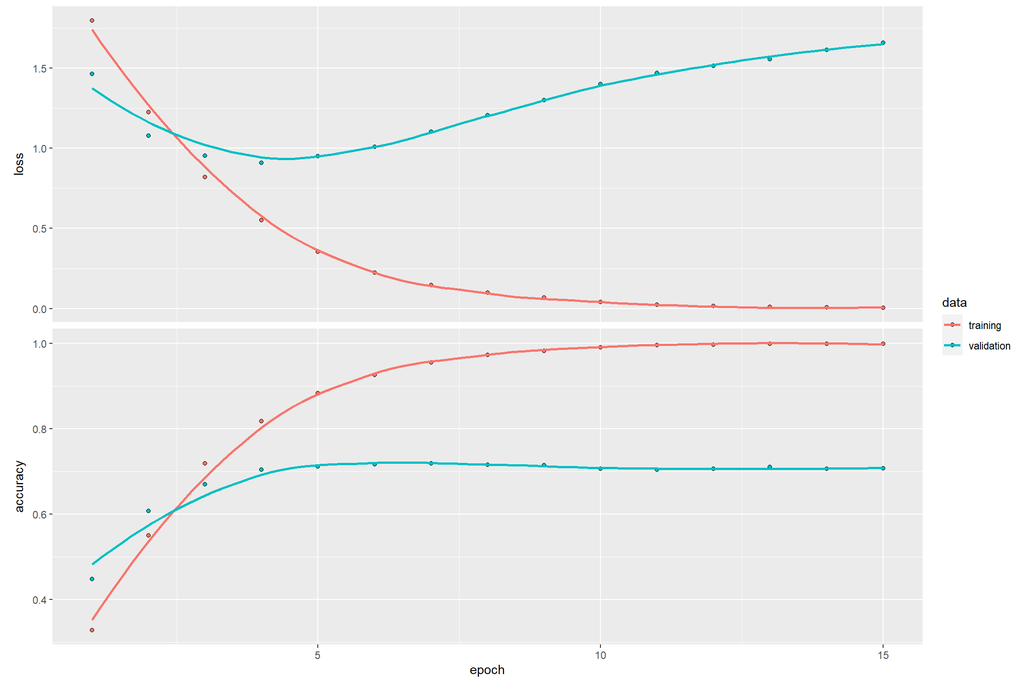

```r
filter_size = 32
embedding_dim = 128
model_bilstm_1dcnn <- keras_model_sequential() %>%
  layer_embedding(input_dim = max_words, output_dim = embedding_dim, input_length = maxlen) %>%
  layer_conv_1d(filters = 32, kernel_size = 5, activation = "relu", input_shape = list(NULL, dim(data)[[-1]])) %>%
  layer_max_pooling_1d(pool_size = 3) %>%
  layer_conv_1d(filters = 32, kernel_size = 5, activation = "relu") %>%
  bidirectional(layer_lstm(units = 32)) %>%
  layer_dense(units = 32, activation = "relu") %>%
  layer_dense(units = dim(y_train)[2], activation = "softmax")

model_bilstm_1dcnn %>% compile(
  optimizer = "adam",
  loss = "categorical_crossentropy",
  metrics = c("accuracy")
)

history <- model_bilstm_1dcnn %>% fit(
  x_train, y_train,
  epochs = 15,
  batch_size = 256,
  validation_split = 0.2
)
plot(history)
```

```r
results_bilstm_1dcnn <- model_bilstm_1dcnn %>% evaluate(x_val, y_val)
results_bilstm_1dcnn
```

```
##      loss  accuracy
## 1.7244973 0.6987754
```

```r
result_list = append(result_list,results_bilstm_1dcnn)

model_bilstm_1dcnn %>% save_model_hdf5("bilstm_1dcnn.h5")
```

## Creating Dataframe of all model accuracies

```r
models = c('NN_embd_100','NN_embd_200','NN_embd_300','NN_embd_400','RNN','Mulilayer RNN','LSTM','BI-LSTM','1d-CNN','1d-CNN-BiLSTM')
loss = c()
accuracy = c()
i=1
for (item in result_list){
  if (i%%2==1){
    loss = append(loss,item)
  }
  else{
    accuracy = append(accuracy,item)
  }
  i=i+1
}

# print(loss)
# print(accuracy)
result_df = data.frame(models = models, loss = loss, accuracy = accuracy)
write.csv(result_df,'results.csv')
```

## Model Evaluation Summary

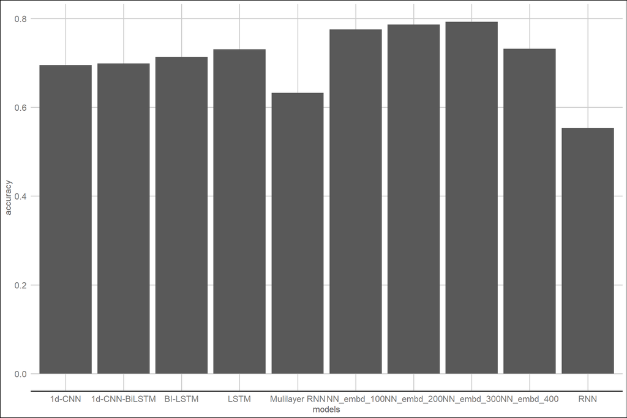

```r
ggplot(data=result_df, aes(y=accuracy, x=models)) +
  geom_bar(position="dodge", stat="identity")+
  theme_gdocs()+
  scale_color_gdocs()+
  scale_fill_brewer(palette = "Paired")
```